[output not shown]

ALUMNO:

Alberto Jiménez Rodríguez

PROGRAMA:

MASTER EN BUSSINESS INTELLIGENCE AND DATA SCIENCE

# CONTENIDO

1. RESUMEN………………………………………………………3
2. INTRODUCCIÓN………………………………………………..4
3. ESTADO DEL ARTE…………………………………………….5
4. OBJETIVOS……………………………………………………6
5. SOLUCIÓN PLANTEADA……………………………………….7
6. EVALUACIÓN…………………………………………………..10
7. RESULTADOS…………………………………………………..11
8. CONCLUSIONES Y TRABAJOS FUTUROS………………………..12
9. REFERENCIAS………………………………………………….14

## RESUMEN

Disponer de un método que nos permita la clasificación de un grupo de muestras de audio mediante el analisis de sus frecuencias. Analisis que posteriormente será visualizado en un espacio bidimensional donde se podrá observar como de parecidas o diferentes son esas muestras.

A traves del barrido frecuencial entre una muestra de referencia (referencia) y las demás muestras de sonido del conjunto, el resultado es procesado se obtiene a traves del método de escalamiento multidimensional basado en el aprendizaje no supervisado, englobado dentro del marco de la reducción de dimensionalidad.

## INTRODUCCIÓN

En el ámbito audiovisual existe un perfil profesional que es el diseñador de sonido, este es un profesional por lo general independiente y se dedica a la creación y el diseño de efectos sonoros con el objetivo de narrar, personificar, generar emociones, retratar espacios sonoros, épocas, y en definitiva crear un universo sonoro con una identidad particular dentro del contexto audiovisual en el que esté trabajando.

El resultado de esta labor es un trabajo metódico y artesanal y el volumen de archivos de sonido que se genera para el desarrollo de un proyecto suele ser enorme, por lo que esto puede ocasionar una perdida de perspectiva tímbrica en el proceso creativo, ya que a mayor volumen de muestras, es fácil que los sonidos acaben siendo parecidos. La consecuencia de ello es la merma en la originalidad del trabajo.

Una herramienta que analice las muestras en las que el profesional está trabajando y determine si existe o no similitud entre las mismas es una solución que ahorrará tiempo a la hora de tomar decisiones de carácter creativo, pues permitirá establecer un punto de partida a partir de una muestra (la que quiera tomarse como referencia en el trabajo) y conocer cuál es el carácter predominante a nivel frecuencial de ese grupo de muestras.

La solución propuesta es la aplicación de una de las técnicas vistas en el módulo de Análisis predictivo con Machine Learning (Diego Calvo), concretamente la referente al escalamiento multidimensional perteneciente al ámbito del aprendizaje no supervisado.

La solución no es innovadora y tampoco pretende serlo, es igualmente cierto que lo principalmente se busca es la implementación del conocimiento adquirido en el apartado de ML en el Master de IEBS de la manera mas original posible, evitando realizar un trabajo con datasets externos mediante un campo como es el audio en el que me siento cómodo desde hace años y a la vez siendo lo más honesto posible con lo aprendido en el Master.

## ESTADO DEL ARTE

Las fuentes que he utilizado como punto de partida y en las que inspirado el trabajo:

Clase practica de Machine Learning del Master de IEBS (Bussiness Intelligence y Big Data) con Diego Calvo sobre la reducción de dimensionalidad y el escalamiento multidimensional.

Caso de estudio en la investigación de los murciélagos con alas de disco de Spix (Thyroptera tricolor), biblioteca de funciones llamada warbleR.

https://marce10.github.io/2020/06/15/Automatic_signal_detection-_a_case_study.html

Sononym. “navegador de muestras de audio”, utilidad que permite la catalogación de las muestras de audio a traves del analisis de las muestras.

No encontré los principios cientificos en los que se apoya esta aplicación de software, porque forma parte del conocimiento interno de una empresa privada, por ese motivo no son publicos. Sin embargo la publicidad del producto que ofrecen se puede entre ver el principio de funcionamiento que hace referencia al análisis de las muestras de sonido mediante Machine Learning para hacer la categorización de muestras.

https://www.sononym.net/docs/manual/similarity-search/#similarity-ratings

https://medium.com/clasificaci%C3%B3n-de-m%C3%BAsica-a-trav%C3%A9s-del-an%C3%A1lisis-de/clasificaci%C3%B3n-de-m%C3%BAsica-a-trav%C3%A9s-del-an%C3%A1lisis-de-se%C3%B1ales-de-audio-1da23481b47c

## OBJETIVOS

Visualizar la relación que hay entre los elementos de un conjunto de muestras y sus frecuencias.

La estrategia para conseguirlo será a traves de los siguientes puntos:

1. Tomar una muestra como referencia y analizar el contenido frecuencial.
2. Comparar las demás muestras con el contenido frecuencial de referencia mediante la correlación cruzada tiempo-frecuencia.
3. Definir el modelo:
   - 3.1 Convertir la matriz de correlación en una matriz de disimilud.
   - 3.2 Ejecutar un escalado multidimensional.
   - 3.3 Calcular las distancias entre los elementos.
4. Evaluar el modelo:
   - 4.1 Visualización en diagrama de Boxplot entre las muestras.
   - 4.2 Visualizacion en diagrama de dispersion.
   - 4.3 Visualizacion en un sistema de coordenadas.

## SOLUCIÓN PLANTEADA

La metodología utilizada se basará en el uso de unas muestras de audio a modo de referencia que permitirán comprobar el funcionamiento correcto del modelo. Tres conjuntos de muestras a modo de referencia con una serie de caracteristas particulares ayudan a determinar el correcto funcionamiento del modelo:

Conjunto A: Muestras con distinta frecuencia, misma duración y con una componente armónica similar (escala musical).

Conjunto B: Muestras con la misma frecuencia, misma duración y con una componente armónica diferente (armónicos).

Conjunto C: Muestras sin ningún tipo de relación timbrica entre ellas y de misma duración que las anteriores (pretenden ser los outlayers del conjunto) elementos disruptivos en el analisis del conjunto.

## Elementos utilizados:

Sintetizador Make Noise 0 Coast (No Coast) su nombre hace alusión a que utiliza técnicas de síntesis de los paradigmas Moog y Buchla (alias “Costa Este” y “Costa Oeste”), sin embargo no es leal a ninguno de los dos, de ahi su nombre 0 COAST “sin costa” y la perspectiva de crear timbres sin la limitación que implica decantarse hacia “una u otra costa”.

La introducción de armónicos en la señal generada es el motivo principal en la elección de este sintetizador.

[figure not shown]

0 Coast Makenoise

http://www.makenoisemusic.com/synthesizers/ohcoast

https://www.soundonsound.com/reviews/make-noise-0-coast

Audacity

Aplicación informática multiplataforma libre, que se puede usar para grabación y edición de audio, distribuido bajo la licencia GPLv2+.

https://es.wikipedia.org/wiki/Audacity

# Procedimiento

Para llevar a cabo el proyecto se relacionó las muestras de sonido con el ejemplo de escalamiento multidimensional, para ello fué necesario el uso de warbleR, una biblioteca de funciones en R que tiene por objeto facilitar el análisis de la estructura de señales acústicas de animales.

```r
library(cluster) # dadisy
library(tuneR)
library(knitr)
library(NatureSounds)
library(seewave)
library(warbleR)
```

```r
library(igraph) # hacer mencion al final no lo he hecho
```

## 1. Tomar una muestra como referencia.

Una vez que ya hemos cargado las bibliotecas de funciones (librerias) para analizar las muestras de sonido, creamos un data frame en el que crearemos las columnas a partir de la introducción del nombre de la muestra que queremos comparar, canal (uno o los dos) , inicio de muestra, final y “selec” = 2.

```r
plantilla <- data.frame(sound.files = "X_pitch-02.wav",
                        selec = 2,
                        channel = 1,
                        start = 0,
                        end = 0.2952381,
                        stringsAsFactors = FALSE)
```

Creamos un objeto “**wave**” a partir del nombre que tenemos en la unica posición del dataframe “**plantilla**”

El objeto “**wave**” tendrá una longitud de 0.2952381 segundos tal y como habiamos indicado en el dataframe, tiempo con el que compararemos todas las demás muestras.

```r
wave_referencia <- read_wave(plantilla, from = plantilla$start[1], to = plantilla$end[1])
wave_referencia
```

```
Wave Object
    Number of Samples:      13020
    Duration (seconds):     0.3
    Samplingrate (Hertz):   44100
    Channels (Mono/Stereo): Mono
    PCM (integer format):   TRUE
    Bit (8/16/24/32/64):    16
```

Establecemos que frecuencia (KHz) queremos visualizar en el eje Y del grafico a partir de los picos de del espectro de frecuencia, independientemente de la muestra.

```r
pico_freq_max <- fpeaks(spec(wave_referencia,dB = "max0" ),nmax = 1,threshold = 0.5)
```

[figure not shown]

[output not shown]

[figure not shown]

```r
por_10 = 10
low_f = 0
high_f <- (pico_freq_max[c(1,0)])*por_10
```

```r
res_wave_referencia <- autoc(wave_referencia, threshold=0.01, plot=FALSE)
```

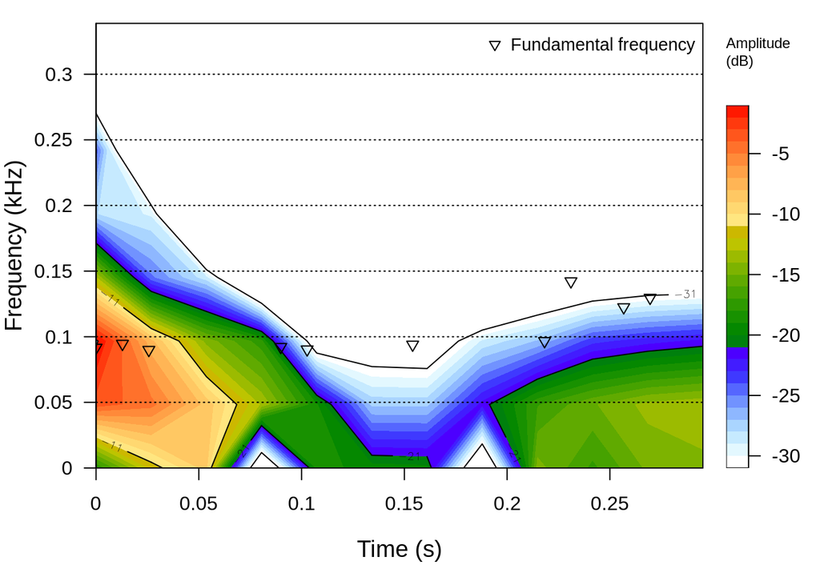

```r
spectro(wave_referencia,
        wl = 1024,
        #ovlp = 99,
        scale = TRUE,
        cont = TRUE,
        flim = c(low_f, high_f),
        noisereduction = TRUE,
        # fastdisp = TRUE,
        dB = 'max0',
        #flog = TRUE,
        grid = TRUE,
        palette = spectro.colors,
)

points(res_wave_referencia, pch=25)
legend("topright", "Fundamental frequency", pch=25, bty="n", cex=0.9)
```